# heart_attack

Oumar Kane

15/03/2022

# Variables selection with heart attack dataset

## We have recuperated a dataset named heart_attack which is very interesting for a debut

## Let’s import the needed libraries further

```r
library(MASS)
library(randomForest)
```

```r
library(VSURF)
library(corrplot)
library(VGAM)
# the glm function will be use because we have binary categorical target
```

## We can recuperate the dataset by indicating the path

```r
heart_data = read.csv("E:/Oumar/Ordinateur Dell/oumar/documents/Cours/IA data forest/master semestre 2/Analyse de données/Projets/Data/Heart_disease/data/heart2.csv")
```

Let’s attach the dataset to manipulate fastly the columns

```r
attach(heart_data)
```

We have to see the five first lines of the dataset and verify the types

```r
head(heart_data)
```

```
##   age sex cp trestbps chol fbs restecg thalach exang oldpeak slope ca thal
## 1  52   1  0      125  212   0       1     168     0     1.0     2  2    3
## 2  53   1  0      140  203   1       0     155     1     3.1     0  0    3
## 3  70   1  0      145  174   0       1     125     1     2.6     0  0    3
## 4  61   1  0      148  203   0       1     161     0     0.0     2  1    3
## 5  62   0  0      138  294   1       1     106     0     1.9     1  3    2
## 6  58   0  0      100  248   0       0     122     0     1.0     1  0    2
##   target
## 1      0
## 2      0
## 3      0
## 4      0
## 5      0
## 6      1
```

The data is already cleaned. We have some categorical variables but those variables are encoded. Let’s profile deeper the dataset.

## Let’s see if the different variables are correlated together with a pairplot

## and a corrplot

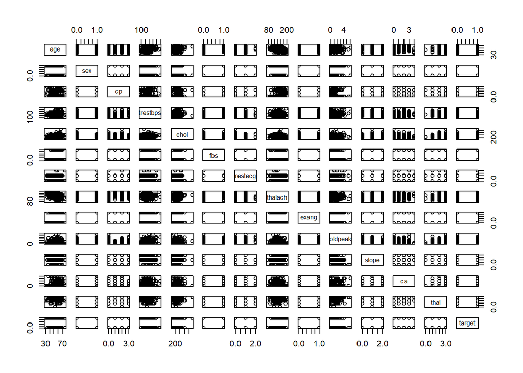

```r
pairs(heart_data)
```

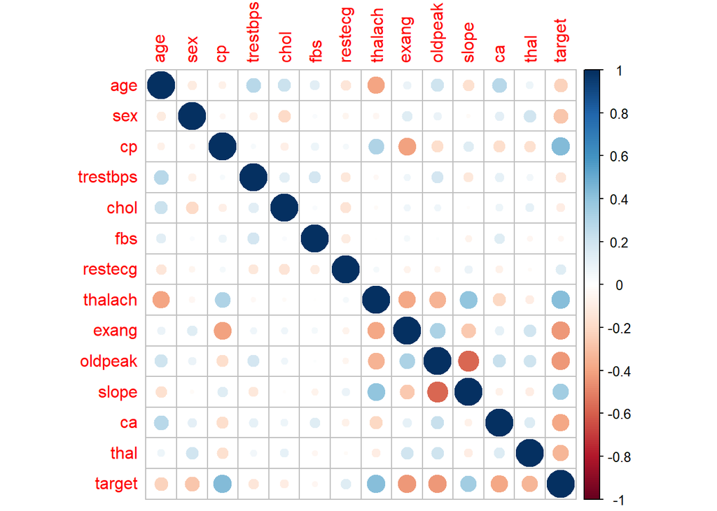

```r
corrplot(cor(heart_data))
```

We didn’t see very well the shapes of the scatter maded beetween variables if we trace the plot with the full dataset. But we can do it again with only few variables.

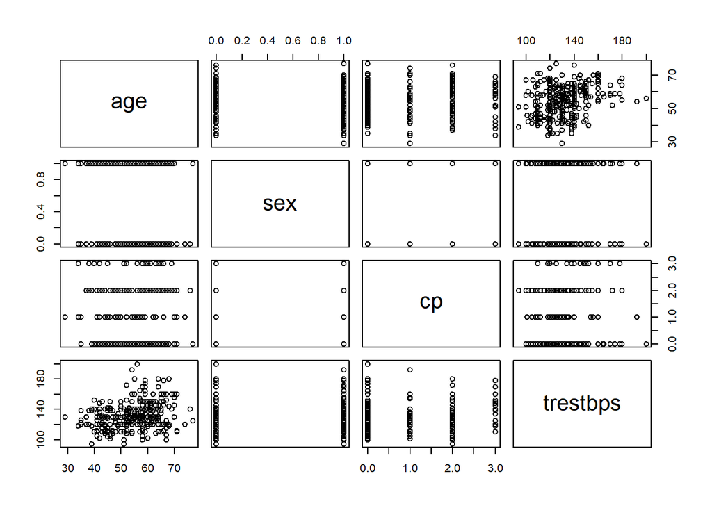

```r
# choose only four first variables
pairs(heart_data[, 1:4])
```

We see that with the categorical variables we did not obtain good distributions. We cannot inter prate the plots with the categorical variables but only with the quantitative variables. Let’s recuperate only the quantitative variables in a new data frame.

```r
quanti = heart_data[, c(1, 4, 5, 8, 10)]
```

Let’s trace a new pairplot without categorical variables

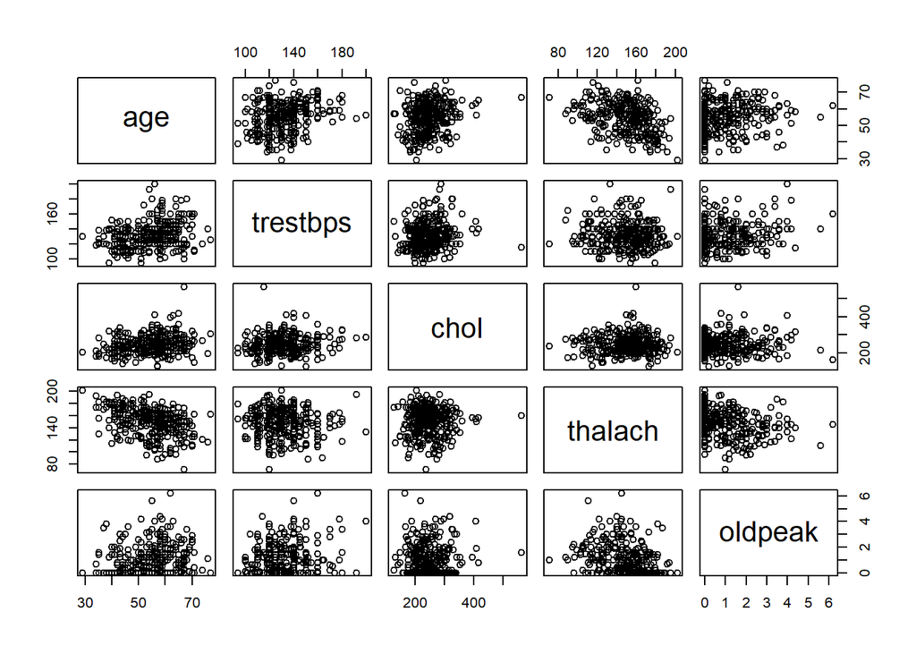

```r
pairs(quanti)
```

We see that some variables like thalach and age or chol and age are correlated

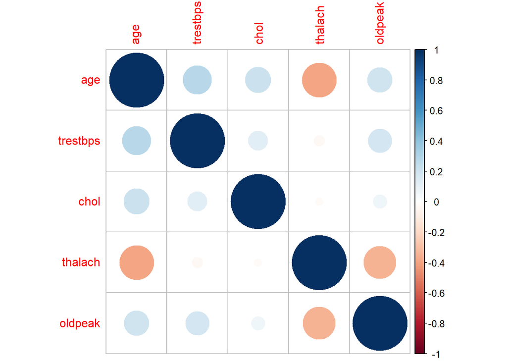

```r
# Let's trace the corrplot to see more clearly the variables interactions
corrplot(cor(quanti))
```

## Preprocessing

### Let’s change the type of the categorical variables to factor

```r
for (i in c(2, 3, 6, 7, 9, 11, 12, 13, 14)){
  heart_data[, i] = as.factor(heart_data[, i])
}
```

### Let’s see if we obtain a good fit with a logistic regression model

We use a logistic regression model because the target `target` is a binary categorical variable

```r
summary(glm(target~., data = heart_data, family = binomial))
```

```
##
## Call:
## glm(formula = target ~ ., family = binomial, data = heart_data)
##
## Deviance Residuals:
##     Min       1Q   Median       3Q      Max
## -2.8582  -0.2917   0.0718   0.4167   3.1908
##
## Coefficients:
##              Estimate Std. Error z value Pr(>|z|)
## (Intercept) -0.081901   2.028691  -0.040 0.967797
## age          0.026846   0.013950   1.924 0.054297 .
## sex1        -1.992347   0.314204  -6.341 2.28e-10 ***
## cp1          0.886380   0.308803   2.870 0.004100 **
## cp2          2.006394   0.286281   7.008 2.41e-12 ***
## cp3          2.409722   0.391965   6.148 7.86e-10 ***
## trestbps    -0.024979   0.006537  -3.821 0.000133 ***
## chol        -0.005462   0.002307  -2.367 0.017914 *
## fbs1         0.380096   0.319620   1.189 0.234356
## restecg1     0.397268   0.217975   1.823 0.068374 .
## restecg2    -0.800417   1.536998  -0.521 0.602530
## thalach      0.021692   0.006525   3.324 0.000886 ***
## exang1      -0.750331   0.248746  -3.016 0.002557 **
## oldpeak     -0.403411   0.132156  -3.053 0.002269 **
## slope1      -0.595618   0.472076  -1.262 0.207057
## slope2       0.799689   0.504500   1.585 0.112941
## ca1         -2.334076   0.286781  -8.139 3.99e-16 ***
## ca2         -3.597039   0.444870  -8.086 6.19e-16 ***
## ca3         -2.288131   0.532138  -4.300 1.71e-05 ***
## ca4          1.565677   0.930256   1.683 0.092363 .
## thal1        2.796813   1.466219   1.908 0.056456 .
## thal2        2.404646   1.421542   1.692 0.090727 .
## thal3        0.991243   1.423972   0.696 0.486359
## ---
## Signif. codes:  0 '***' 0.001 '**' 0.01 '*' 0.05 '.' 0.1 ' ' 1
##
## (Dispersion parameter for binomial family taken to be 1)
##
##     Null deviance: 1420.24  on 1024  degrees of freedom
## Residual deviance:  606.82  on 1002  degrees of freedom
## AIC: 652.82
##
## Number of Fisher Scoring iterations: 6
```

## We can begin the selection using the likelihood ratio

```r
# create a function calculating the likelihood ratio
LRT_dev = function(mod1, mod2){
  p_value =  1 - pchisq(deviance(mod1) - deviance(mod2), df.residual(mod1) - df.residual(mod2))
  result = p_value < 0.05
  print(paste("p_value is : ", p_value))
  print(paste("p_value < 0.05 : ", as.logical(p_value < 0.05)))
  return(result)
}
```

## Forward selection with likelihood ratio

### age

```r
model0 = glm(target~1, data = heart_data, family = binomial)
model1 = glm(target~age, data = heart_data, family = binomial)

LRT_dev(model0, model1)
```

```
## [1] "p_value is :  1.10245146345278e-13"
## [1] "p_value < 0.05 :  TRUE"
```

```
## [1] TRUE
```

The age variable is relevant, we can maintain it

### sex

```r
model2 = glm(target~age+sex, data = heart_data, family = binomial)

LRT_dev(model1, model2)
```

```
## [1] "p_value is :  0"
## [1] "p_value < 0.05 :  TRUE"
```

```
## [1] TRUE
```

The sex variable is relevant, we can maintain it

### cp

```r
model3 = glm(target~age+sex+cp, data = heart_data, family = binomial)

LRT_dev(model2, model3)
```

```
## [1] "p_value is :  0"
## [1] "p_value < 0.05 :  TRUE"
```

```
## [1] TRUE
```

The cp variable is relevant, we can maintain it

### trestbps

```r
model4 = glm(target~age+sex+cp+trestbps, data = heart_data, family = binomial)

LRT_dev(model3, model4)
```

```
## [1] "p_value is :  0.000169102807049737"
## [1] "p_value < 0.05 :  TRUE"
```

```
## [1] TRUE
```

The trestbps variable is relevant, we can maintain it

### chol

```r
model5 = glm(target~age+sex+cp+trestbps+chol, data = heart_data, family = binomial)

LRT_dev(model4, model5)
```

```
## [1] "p_value is :  0.0011530054348099"
## [1] "p_value < 0.05 :  TRUE"
```

```
## [1] TRUE
```

The chol variable is relevant, we can maintain it

### fbs

```r
model6 = glm(target~age+sex+cp+trestbps+chol+fbs, data = heart_data, family = binomial)

LRT_dev(model5, model6)
```

```
## [1] "p_value is :  0.518289635253512"
## [1] "p_value < 0.05 :  FALSE"
```

```
## [1] FALSE
```

The fbs variable is not relevant, we can exclude it

### restecg

```r
model7 = glm(target~age+sex+cp+trestbps+chol+restecg, data = heart_data, family = binomial)

LRT_dev(model5, model7)
```

```
## [1] "p_value is :  0.00375926672530991"
## [1] "p_value < 0.05 :  TRUE"
```

```
## [1] TRUE
```

The restecg variable is relevant, we can maintain it

### thalach

```r
model8 = glm(target~age+sex+cp+trestbps+chol+restecg+thalach, data = heart_data, family = binomial)

LRT_dev(model7, model8)
```

```
## [1] "p_value is :  1.22124532708767e-15"
## [1] "p_value < 0.05 :  TRUE"
```

```
## [1] TRUE
```

The thalach variable is relevant, we can maintain it

### exang

```r
model9 = glm(target~age+sex+cp+trestbps+chol+restecg+thalach+exang, data = heart_data, family = binomial)

LRT_dev(model8, model9)
```

```
## [1] "p_value is :  7.35191679746006e-06"
## [1] "p_value < 0.05 :  TRUE"
```

```
## [1] TRUE
```

The exang variable is relevant, we can maintain it

### oldpeak

```r
model10 = glm(target~age+sex+cp+trestbps+chol+restecg+thalach+exang+oldpeak, data = heart_data, family = binomial)

LRT_dev(model9, model10)
```

```
## [1] "p_value is :  1.54321000422897e-14"
## [1] "p_value < 0.05 :  TRUE"
```

```
## [1] TRUE
```

The oldpeak variable is relevant, we can maintain it

### slope

```r
model11 = glm(target~age+sex+cp+trestbps+chol+restecg+thalach+exang+oldpeak+slope, data = heart_data, family = binomial)

LRT_dev(model10, model11)
```

```
## [1] "p_value is :  0.000864762685505505"
## [1] "p_value < 0.05 :  TRUE"
```

```
## [1] TRUE
```

The slope variable is relevant, we can maintain it

### ca

```r
model12 = glm(target~age+sex+cp+trestbps+chol+restecg+thalach+exang+oldpeak+slope+ca, data = heart_data, family = binomial)

LRT_dev(model11, model12)
```

```
## [1] "p_value is :  0"
## [1] "p_value < 0.05 :  TRUE"
```

```
## [1] TRUE
```

The ca variable is relevant, we can maintain it

### thal

```r
model13 = glm(target~age+sex+cp+trestbps+chol+restecg+thalach+exang+oldpeak+slope+ca+thal, data = heart_data, family = binomial)

LRT_dev(model12, model13)
```

```
## [1] "p_value is :  2.78633116579385e-10"
## [1] "p_value < 0.05 :  TRUE"
```

```
## [1] TRUE
```

The thal variable is relevant, we can maintain it

### Conclusion :

The final model doesn’t contain the fbs variable :

```r
final_model_forw = model13
# summary of the model
summary(final_model_forw)
```

```
##
## Call:
## glm(formula = target ~ age + sex + cp + trestbps + chol + restecg +
##     thalach + exang + oldpeak + slope + ca + thal, family = binomial,
##     data = heart_data)
##
## Deviance Residuals:
##     Min       1Q   Median       3Q      Max
## -2.8702  -0.2991   0.0755   0.4399   3.1679
##
## Coefficients:
##              Estimate Std. Error z value Pr(>|z|)
## (Intercept) -0.119738   2.107657  -0.057 0.954696
## age          0.026592   0.013945   1.907 0.056534 .
## sex1        -1.969469   0.313760  -6.277 3.45e-10 ***
## cp1          0.899337   0.307083   2.929 0.003404 **
## cp2          2.068496   0.282871   7.313 2.62e-13 ***
## cp3          2.453102   0.390858   6.276 3.47e-10 ***
## trestbps    -0.023878   0.006437  -3.710 0.000208 ***
## chol        -0.005238   0.002294  -2.284 0.022386 *
## restecg1     0.393543   0.218002   1.805 0.071039 .
## restecg2    -0.851297   1.525128  -0.558 0.576721
## thalach      0.022018   0.006525   3.374 0.000740 ***
## exang1      -0.723590   0.247712  -2.921 0.003488 **
## oldpeak     -0.416989   0.131778  -3.164 0.001554 **
## slope1      -0.618069   0.469275  -1.317 0.187815
## slope2       0.750442   0.500569   1.499 0.133828
## ca1         -2.281180   0.280992  -8.118 4.73e-16 ***
## ca2         -3.520334   0.436022  -8.074 6.82e-16 ***
## ca3         -2.192514   0.521209  -4.207 2.59e-05 ***
## ca4          1.719545   0.962903   1.786 0.074133 .
## thal1        2.684574   1.571897   1.708 0.087663 .
## thal2        2.234492   1.525980   1.464 0.143112
## thal3        0.811145   1.527764   0.531 0.595463
## ---
## Signif. codes:  0 '***' 0.001 '**' 0.01 '*' 0.05 '.' 0.1 ' ' 1
##
## (Dispersion parameter for binomial family taken to be 1)
##
##     Null deviance: 1420.24  on 1024  degrees of freedom
## Residual deviance:  608.24  on 1003  degrees of freedom
## AIC: 652.24
##
## Number of Fisher Scoring iterations: 6
```

## Backward selection with likelihood ratio

### age

```r
model0 = glm(target~., data = heart_data, family = binomial)
model1 = glm(target~.-age, data = heart_data, family = binomial)

LRT_dev(model1, model0)
```

```
## [1] "p_value is :  0.0532387547007871"
## [1] "p_value < 0.05 :  FALSE"
```

```
## [1] FALSE
```

The age variable is not relevant, we can exclude it

### sex

```r
model2 = glm(target~.-age-sex, data = heart_data, family = binomial)

LRT_dev(model2, model1)
```

```
## [1] "p_value is :  6.34337027349829e-12"
## [1] "p_value < 0.05 :  TRUE"
```

```
## [1] TRUE
```

The sex variable is relevant, we can maintain it

### cp

```r
model3 = glm(target~.-age-cp, data = heart_data, family = binomial)

LRT_dev(model3, model1)
```

```
## [1] "p_value is :  4.44089209850063e-16"
## [1] "p_value < 0.05 :  TRUE"
```

```
## [1] TRUE
```

The cp variable is relevant, we can maintain it

### trestbps

```r
model4 = glm(target~.-age-trestbps, data = heart_data, family = binomial)

LRT_dev(model4, model1)
```

```
## [1] "p_value is :  0.000464297725977225"
## [1] "p_value < 0.05 :  TRUE"
```

```
## [1] TRUE
```

The trestbps variable is relevant, we can maintain it

### chol

```r
model5 = glm(target~.-age-chol, data = heart_data, family = binomial)

LRT_dev(model5, model1)
```

```
## [1] "p_value is :  0.0343792772062943"
## [1] "p_value < 0.05 :  TRUE"
```

```
## [1] TRUE
```

The chol variable is relevant, we can maintain it

### fbs

```r
model6 = glm(target~.-age-fbs, data = heart_data, family = binomial)

LRT_dev(model6, model1)
```

```
## [1] "p_value is :  0.243700583458427"
## [1] "p_value < 0.05 :  FALSE"
```

```
## [1] FALSE
```

The fbs variable is not relevant, we can exclude it

### restecg

```r
model7 = glm(target~.-age-fbs-restecg, data = heart_data, family = binomial)

LRT_dev(model7, model6)
```

```
## [1] "p_value is :  0.191442156594169"
## [1] "p_value < 0.05 :  FALSE"
```

```
## [1] FALSE
```

The restecg variable is not relevant, we can exclude it

### thalach

```r
model8 = glm(target~.-age-fbs-restecg-thalach, data = heart_data, family = binomial)

LRT_dev(model8, model7)
```

```
## [1] "p_value is :  0.00233122695649768"
## [1] "p_value < 0.05 :  TRUE"
```

```
## [1] TRUE
```

The thalach variable is relevant, we can maintain it

### exang

```r
model9 = glm(target~.-age-fbs-restecg-exang, data = heart_data, family = binomial)

LRT_dev(model9, model7)
```

```
## [1] "p_value is :  0.00307809092902378"
## [1] "p_value < 0.05 :  TRUE"
```

```
## [1] TRUE
```

The exang variable is relevant, we can maintain it

### oldpeak

```r
model10 = glm(target~.-age-fbs-restecg-oldpeak, data = heart_data, family = binomial)

LRT_dev(model10, model7)
```

```
## [1] "p_value is :  0.000447998959877682"
## [1] "p_value < 0.05 :  TRUE"
```

```
## [1] TRUE
```

The oldpeak variable is relevant, we can maintain it

### slope

```r
model11 = glm(target~.-age-fbs-restecg-slope, data = heart_data, family = binomial)

LRT_dev(model11, model7)
```

```
## [1] "p_value is :  1.08118381503264e-06"
## [1] "p_value < 0.05 :  TRUE"
```

```
## [1] TRUE
```

The slope variable is relevant, we can maintain it

### ca

```r
model12 = glm(target~.-age-fbs-restecg-ca, data = heart_data, family = binomial)

LRT_dev(model12, model7)
```

```
## [1] "p_value is :  0"
## [1] "p_value < 0.05 :  TRUE"
```

```
## [1] TRUE
```

The ca variable is relevant, we can maintain it

### thal

```r
model13 = glm(target~.-age-fbs-restecg-thal, data = heart_data, family = binomial)

LRT_dev(model13, model7)
```

```
## [1] "p_value is :  8.00956745372616e-10"
## [1] "p_value < 0.05 :  TRUE"
```

```
## [1] TRUE
```

The thal variable is relevant, we can maintain it

### conclusion :

The final model doesn’t contain the following variables : age, fbs and restecg.

```r
final_model_back = model7
summary(final_model_back)
```

```
##
## Call:
## glm(formula = target ~ . - age - fbs - restecg, family = binomial,
##     data = heart_data)
##
## Deviance Residuals:
##     Min       1Q   Median       3Q      Max
## -2.8426  -0.3117   0.0821   0.4410   3.2375
##
## Coefficients:
##              Estimate Std. Error z value Pr(>|z|)
## (Intercept)  1.759212   2.125365   0.828 0.407828
## sex1        -2.013263   0.309750  -6.500 8.05e-11 ***
## cp1          0.954620   0.306490   3.115 0.001841 **
## cp2          2.109382   0.282959   7.455 9.01e-14 ***
## cp3          2.442079   0.384484   6.352 2.13e-10 ***
## trestbps    -0.021768   0.005975  -3.643 0.000269 ***
## chol        -0.005319   0.002167  -2.454 0.014113 *
## thalach      0.017998   0.006114   2.944 0.003242 **
## exang1      -0.729760   0.246122  -2.965 0.003027 **
## oldpeak     -0.435713   0.127416  -3.420 0.000627 ***
## slope1      -0.593005   0.460981  -1.286 0.198304
## slope2       0.770110   0.491292   1.568 0.116993
## ca1         -2.224647   0.273918  -8.122 4.60e-16 ***
## ca2         -3.270601   0.413742  -7.905 2.68e-15 ***
## ca3         -2.141769   0.537328  -3.986 6.72e-05 ***
## ca4          1.581474   0.881925   1.793 0.072940 .
## thal1        2.800038   1.787780   1.566 0.117300
## thal2        2.304987   1.747861   1.319 0.187254
## thal3        0.948599   1.748739   0.542 0.587510
## ---
## Signif. codes:  0 '***' 0.001 '**' 0.01 '*' 0.05 '.' 0.1 ' ' 1
##
## (Dispersion parameter for binomial family taken to be 1)
##
##     Null deviance: 1420.24  on 1024  degrees of freedom
## Residual deviance:  615.22  on 1006  degrees of freedom
## AIC: 653.22
##
## Number of Fisher Scoring iterations: 6
```

## Let’s make variables selection with the stepwise trick

The stepwise function (stepAIC) take as main parameters the model (logistic) and the direction which can be forward, backward or both. We can choose the both direction to obtain the best possible model. The time complexity of the stepwise method is very high but we will finally obtain a good selection.

```r
model = glm(target~., data = heart_data, family = binomial)
step.model = stepAIC(model, direction = "both")
```

```
## Start:  AIC=652.82
## target ~ age + sex + cp + trestbps + chol + fbs + restecg + thalach +
##     exang + oldpeak + slope + ca + thal
##
##            Df Deviance    AIC
## - fbs       1   608.24 652.24
## - restecg   2   610.59 652.59
## <none>          606.82 652.82
## - age       1   610.55 654.55
## - chol      1   612.27 656.27
## - exang     1   615.88 659.88
## - oldpeak   1   616.56 660.56
## - thalach   1   618.58 662.58
## - trestbps  1   622.06 666.06
## - slope     2   634.80 676.80
## - thal      3   653.01 693.01
## - sex       1   652.38 696.38
## - cp        3   679.09 719.09
## - ca        4   747.81 785.81
##
## Step:  AIC=652.24
## target ~ age + sex + cp + trestbps + chol + restecg + thalach +
##     exang + oldpeak + slope + ca + thal
##
##            Df Deviance    AIC
## - restecg   2   612.01 652.01
## <none>          608.24 652.24
## + fbs       1   606.82 652.82
## - age       1   611.91 653.91
## - chol      1   613.31 655.31
## - exang     1   616.75 658.75
## - oldpeak   1   618.75 660.75
## - thalach   1   620.37 662.37
## - trestbps  1   622.53 664.53
## - slope     2   635.44 675.44
## - thal      3   655.70 693.70
## - sex       1   652.92 694.92
## - cp        3   686.09 724.09
## - ca        4   748.43 784.43
##
## Step:  AIC=652.01
## target ~ age + sex + cp + trestbps + chol + thalach + exang +
##     oldpeak + slope + ca + thal
##
##            Df Deviance    AIC
## <none>          612.01 652.01
## + restecg   2   608.24 652.24
## + fbs       1   610.59 652.59
## - age       1   615.22 653.22
## - chol      1   618.87 656.87
## - exang     1   620.31 658.31
## - oldpeak   1   622.98 660.98
## - thalach   1   624.19 662.19
## - trestbps  1   628.65 666.65
## - slope     2   640.87 676.87
## - thal      3   657.38 691.38
## - sex       1   658.37 696.37
## - cp        3   690.25 724.25
## - ca        4   754.60 786.60
```

```r
# summary of the stepwise model
summary(step.model)
```

```
##
## Call:
## glm(formula = target ~ age + sex + cp + trestbps + chol + thalach +
##     exang + oldpeak + slope + ca + thal, family = binomial, data = heart_data)
##
## Deviance Residuals:
##     Min       1Q   Median       3Q      Max
## -2.8172  -0.3056   0.0789   0.4425   3.2446
##
## Coefficients:
##              Estimate Std. Error z value Pr(>|z|)
## (Intercept)  0.432526   2.194867   0.197 0.843778
## age          0.024750   0.013866   1.785 0.074273 .
## sex1        -1.987341   0.311799  -6.374 1.84e-10 ***
## cp1          0.925378   0.307153   3.013 0.002589 **
## cp2          2.086274   0.282856   7.376 1.63e-13 ***
## cp3          2.424310   0.387894   6.250 4.11e-10 ***
## trestbps    -0.025043   0.006309  -3.969 7.21e-05 ***
## chol        -0.005976   0.002244  -2.663 0.007740 **
## thalach      0.022119   0.006561   3.371 0.000748 ***
## exang1      -0.714079   0.247315  -2.887 0.003885 **
## oldpeak     -0.414750   0.128417  -3.230 0.001239 **
## slope1      -0.607436   0.461220  -1.317 0.187832
## slope2       0.795311   0.491264   1.619 0.105467
## ca1         -2.321347   0.280060  -8.289  < 2e-16 ***
## ca2         -3.468958   0.429465  -8.077 6.62e-16 ***
## ca3         -2.272658   0.534734  -4.250 2.14e-05 ***
## ca4          1.682084   0.917953   1.832 0.066887 .
## thal1        2.761054   1.715714   1.609 0.107556
## thal2        2.253987   1.674329   1.346 0.178237
## thal3        0.892851   1.675488   0.533 0.594110
## ---
## Signif. codes:  0 '***' 0.001 '**' 0.01 '*' 0.05 '.' 0.1 ' ' 1
##
## (Dispersion parameter for binomial family taken to be 1)
##
##     Null deviance: 1420.24  on 1024  degrees of freedom
## Residual deviance:  612.01  on 1005  degrees of freedom
## AIC: 652.01
##
## Number of Fisher Scoring iterations: 6
```

## Make selection with the random forest classification model :

This method selects the best variables by using the random forest classification model. The random forest model is known to be a non parametric model.

```r
forest.model = randomForest(target~., data = heart_data, importance = TRUE)
```

```r
summary(forest.model)
```

```
##                 Length Class  Mode
## call               4   -none- call
## type               1   -none- character
## predicted       1025   factor numeric
## err.rate        1500   -none- numeric
## confusion          6   -none- numeric
## votes           2050   matrix numeric
## oob.times       1025   -none- numeric
## classes            2   -none- character
## importance        52   -none- numeric
## importanceSD      39   -none- numeric
## localImportance    0   -none- NULL
## proximity          0   -none- NULL
## ntree              1   -none- numeric
## mtry               1   -none- numeric
## forest            14   -none- list
## y               1025   factor numeric
## test               0   -none- NULL
## inbag              0   -none- NULL
## terms              3   terms  call
```

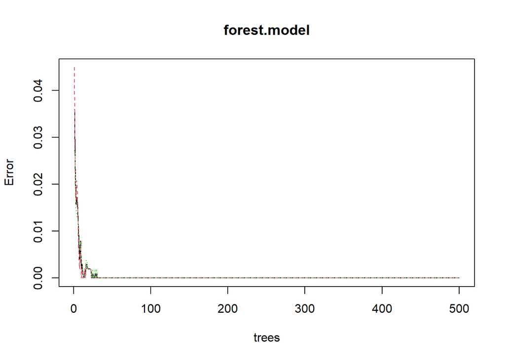

```r
# plot the OOB errors
plot(forest.model)
```

### Let’s plot the classification of the variables

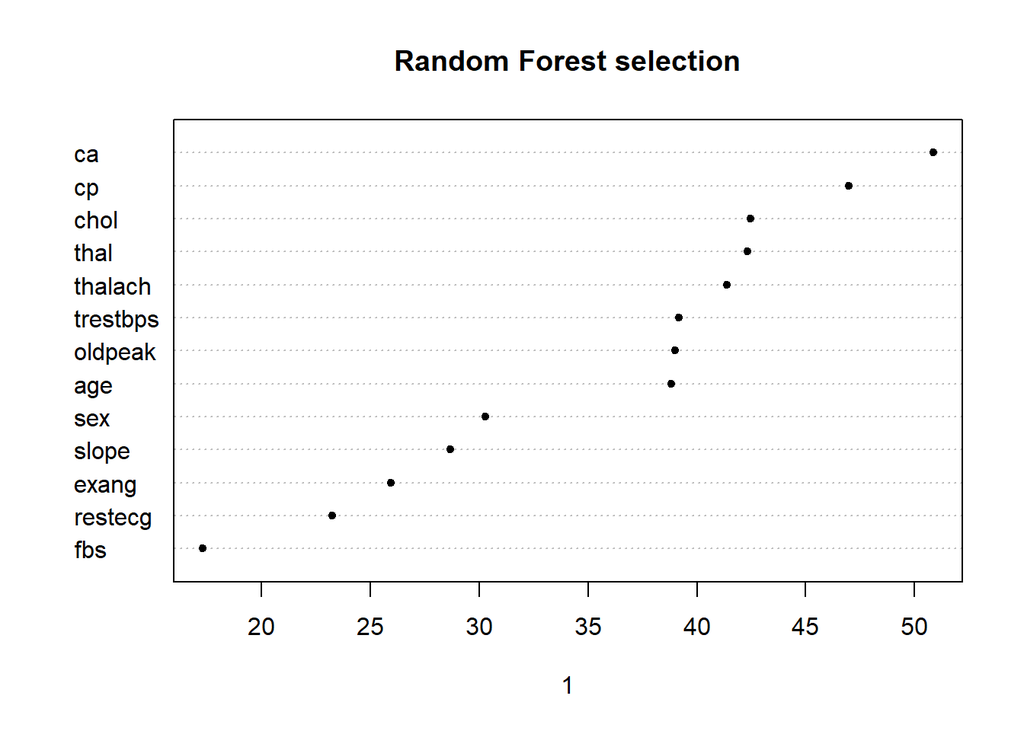

```r
varImpPlot(forest.model, type = 1, c = 1, pch = 20, cex = 1, main = "Random Forest selection")
```

With the VSURF package we will interprate the selection and visualize the best choices.

```r
y = heart_data[, 1]
x = heart_data[, -1]
th1 = VSURF_thres(x, y, ntree = 500)
```

```
## Thresholding step
## Estimated computational time (on one core): 114.5 sec.
##
```

```r
vs1 = VSURF_interp(x, y, vars = th1$varselect.thres)
```

```
##
## Interpretation step (on 13 variables)
## Estimated computational time (on one core): between 113.7 sec. and  523.3 sec.
##
```

Let’s visualize the number of variables choosed

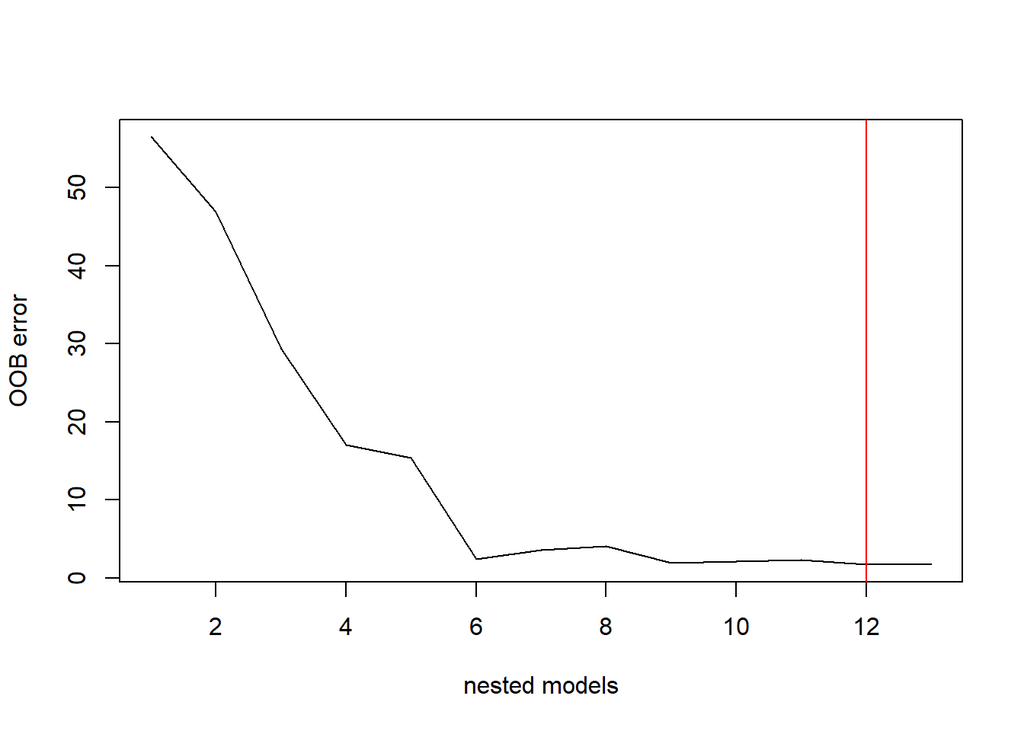

```r
plot(vs1)
```

```r
names(heart_data)[vs1$varselect.interp]
```

```
##  [1] "restecg"  "slope"    "cp"       "trestbps" "exang"    "sex"
##  [7] "thal"     "ca"       "fbs"      "oldpeak"  "age"      "thalach"
```

```r
get_formula_add = function(target, variables){
 return(as.formula(                      # Create formula
  paste(paste(target, " ~ "), paste(variables, collapse = " + "))))
}
get_formula_rem = function(target, variables, all_variables){
 return(as.formula(                      # Create formula
  paste(paste(target, " ~ "), paste(paste(paste(all_variables, collapse = " + "), " - ")), paste(variables, collapse = " - "))))
}
```

## We can recuperate in a variable the columns names to test our function

```r
variables = names(heart_data)[-length(heart_data)]
glm(get_formula_add("target", variables), data = heart_data, family = binomial)
```

```
##
## Call:  glm(formula = get_formula_add("target", variables), family = binomial,
##     data = heart_data)
##
## Coefficients:
## (Intercept)          age         sex1          cp1          cp2          cp3
##   -0.081901     0.026846    -1.992347     0.886380     2.006394     2.409722
##    trestbps         chol         fbs1     restecg1     restecg2      thalach
##   -0.024979    -0.005462     0.380096     0.397268    -0.800417     0.021692
##      exang1      oldpeak       slope1       slope2          ca1          ca2
##   -0.750331    -0.403411    -0.595618     0.799689    -2.334076    -3.597039
##         ca3          ca4        thal1        thal2        thal3
##   -2.288131     1.565677     2.796813     2.404646     0.991243
##
## Degrees of Freedom: 1024 Total (i.e. Null);  1002 Residual
## Null Deviance:       1420
## Residual Deviance: 606.8     AIC: 652.8
```

Our function goes well as we expected it.

## Let’s made a function that perform directly the LRT analysis

```r
# test the list loop over
grab_elements = function(variables){
  for(val in variables){
    print(val)
  }
}

process_LRT = function(target, variables, data, model, family, mode = "forward"){
  mod = NULL
  if(mode == "forward"){
    print("Forward Selection :")
    print("--------------------------")
    mod = model(target~1, data = data, family = family)
    testing_variables = c()
    j = 1
    for(i in 1:length(variables)){
      testing_variables[j] = variables[i]
      new_model = model(get_formula_add(target, testing_variables), data = data, family = family)
      print(paste("Variable ", variables[i]))
      if(LRT_dev(mod, new_model) == 1){
        j = j + 1
        mod = new_model
        print(paste("The variable ", paste(variables[i], " is relevant")))
      }
      else{
        print(paste("The variable ", paste(variables[i], " is not relevant")))
      }
      print("========================================================================================================")
    }
  }
  else if(mode == "backward"){
    print("Backward Selection :")
    print("--------------------------")
    mod = model(get_formula_add(target, variables), data = data, family = family)
    testing_variables = c()
    j = 1
    for(i in 1:length(variables)){
      testing_variables[j] = variables[i]
      new_model = model(get_formula_rem(target, testing_variables, variables), data = data, family = family)
      print(paste("Variable ", variables[i]))
      if(LRT_dev(new_model, mod) == 0){
        j = j + 1
        mod = new_model
        print(paste("The variable ", paste(variables[i], " is not relevant")))
      }
      else{
        print(paste("The variable ", paste(variables[i], " is relevant")))
      }
      print("========================================================================================================")
    }
  }
  else{
    print(paste(paste("Error ! The following choice ", mode), " doesn't exist"))
  }
  return(mod)
}
```

### We can process the forward selection with the created function.

```r
model_final = process_LRT("target", variables, heart_data, glm, binomial, "forward")
```

```
## [1] "Forward Selection :"
## [1] "--------------------------"
## [1] "Variable  age"
## [1] "p_value is :  1.10245146345278e-13"
## [1] "p_value < 0.05 :  TRUE"
## [1] "The variable  age  is relevant"
## [1] "========================================================================================================"
## [1] "Variable  sex"
## [1] "p_value is :  0"
## [1] "p_value < 0.05 :  TRUE"
## [1] "The variable  sex  is relevant"
## [1] "========================================================================================================"
## [1] "Variable  cp"
## [1] "p_value is :  0"
## [1] "p_value < 0.05 :  TRUE"
```

[output cut: 52 more lines]

### Let’s process now the backward selection.

```r
model_final = process_LRT("target", variables, heart_data, glm, binomial, "backward")
```

```
## [1] "Backward Selection :"
## [1] "--------------------------"
## [1] "Variable  age"
## [1] "p_value is :  0.0532387547007871"
## [1] "p_value < 0.05 :  FALSE"
## [1] "The variable  age  is not relevant"
## [1] "========================================================================================================"
## [1] "Variable  sex"
## [1] "p_value is :  6.34337027349829e-12"
## [1] "p_value < 0.05 :  TRUE"
## [1] "The variable  sex  is relevant"
## [1] "========================================================================================================"
## [1] "Variable  cp"
## [1] "p_value is :  4.44089209850063e-16"
## [1] "p_value < 0.05 :  TRUE"
```

[output cut: 52 more lines]

We created a function which can process the likelihood ratio on a full data set. But we can also create a function which can process the likelihood ratio on a few variables only. We must, before that, maintain some variables as relevant and we will investigate, after that, the another variables to check if their are relevant or not. Let’s create the function and test it with the not relevant variables.

## Match function.

The match function will be made like the process LRT function but with different arguments

```r
match_variables_LRT = function(target, relevant_variables, variables_to_check, data, model, family){
  print("Let's check if the provided variables are important :")
  print("--------------------------")
  mod = model(get_formula_add(target, relevant_variables), data = data, family = family)
  testing_variables = relevant_variables
  j = length(relevant_variables) + 1
  for(i in 1:length(variables_to_check)){
      testing_variables[j] = variables_to_check[i]
      new_model = model(get_formula_add(target, testing_variables), data = data, family = family)
      print(paste("Variable ", variables_to_check[i]))
      if(LRT_dev(mod, new_model) == 1){
        print(paste("The variable ", paste(variables_to_check[i], " is relevant")))
      }
      else{
        print(paste("The variable ", paste(variables_to_check[i], " is not relevant")))
      }
      print("========================================================================================================")
  }
}
```

## Test some variables with the match function

The variables to test with the match function are listed as following : age, fbs, chol and restecg. The another variables will be considerate as relevant.

```r
# recuperate before that the relevant variables
variables_to_exclude = c('target', 'age', 'fbs', 'chol', 'restecg')
relevant_variables = names(heart_data[,-which(names(heart_data) %in% variables_to_exclude)])
variables_to_check = variables_to_exclude[-1]
match_variables_LRT("target", relevant_variables, variables_to_check, heart_data, glm, "binomial")
```

```
## [1] "Let's check if the provided variables are important :"
## [1] "--------------------------"
## [1] "Variable  age"
## [1] "p_value is :  0.143093362973493"
## [1] "p_value < 0.05 :  FALSE"
## [1] "The variable  age  is not relevant"
## [1] "========================================================================================================"
## [1] "Variable  fbs"
## [1] "p_value is :  0.330881519567919"
## [1] "p_value < 0.05 :  FALSE"
## [1] "The variable  fbs  is not relevant"
## [1] "========================================================================================================"
## [1] "Variable  chol"
## [1] "p_value is :  0.0160242279905701"
## [1] "p_value < 0.05 :  TRUE"
## [1] "The variable  chol  is relevant"
## [1] "========================================================================================================"
## [1] "Variable  restecg"
## [1] "p_value is :  0.0836491885402908"
## [1] "p_value < 0.05 :  FALSE"
## [1] "The variable  restecg  is not relevant"
## [1] "========================================================================================================"
```

**Conclusion**: Only the variable chol will be maintain. The not relevant variables will be finally : age, fbs and restecg. We can create the final model which will contains only the relevant variables.

### final model

```r
# update the relevant variables
variables_to_exclude = c('target', 'age', 'fbs', 'restecg')
relevant_variables = names(heart_data[,-which(names(heart_data) %in% variables_to_exclude)])
final_model = glm(get_formula_add("target", relevant_variables), data = heart_data, family = "binomial")
print(final_model)
```

```
##
## Call:  glm(formula = get_formula_add("target", relevant_variables),
##     family = "binomial", data = heart_data)
##
## Coefficients:
## (Intercept)         sex1          cp1          cp2          cp3     trestbps
##    1.759212    -2.013263     0.954620     2.109382     2.442079    -0.021768
##        chol      thalach       exang1      oldpeak       slope1       slope2
##   -0.005319     0.017998    -0.729760    -0.435713    -0.593005     0.770110
##         ca1          ca2          ca3          ca4        thal1        thal2
##   -2.224647    -3.270601    -2.141769     1.581474     2.800038     2.304987
##       thal3
##    0.948599
##
## Degrees of Freedom: 1024 Total (i.e. Null);  1006 Residual
## Null Deviance:       1420
## Residual Deviance: 615.2     AIC: 653.2
```